# Statistik Projektarbeit

[figure not shown]

[figure not shown]

[figure not shown]

[figure not shown]

[figure not shown]

[figure not shown]

[figure not shown]

[figure not shown]

[figure not shown]

[figure not shown]

[figure not shown]

[figure not shown]

**Vorgaben:**

- Signifikanzniveau: 1 − 𝛼 = 95%
- Grenzwert der Teststärke: 1 − 𝛽 = 90%
- Angabe von H0 und H1 falls wählbar
- Multiples Testen kann, muss aber nicht berücksichtigt werden
- Geben Sie zu allen Tests die Nullhypothese 𝐻0 und die Alternativhypothese 𝐻1an, wenn diese wählbar sind

# Aufgabe 1

#### Aufgabenstellung

Im Rahmen der Lieferantenreduzierung sollen drei Lieferanten, die verschiedene technische Bauteile und Hilfsmittel liefern, auf Zuverlässigkeit ihrer gelieferten Artikel untersucht werden.

1. Unterscheidet sich die Produktzuverlässigkeit der einzelnen Lieferanten signifikant voneinander?
2. Gibt es einen Zusammenhang zwischen Produktkategorie und Zuverlässigkeit?

#### Vorüberlegungen

- Wir haben zwei nominale Variablen *Lieferant* (Lieferant A, B, C) und *Produktgruppe* (Mechanik, Elektronik, Werkzeuge, Hilfsstoffe) sowie die ordinale Variable *Zuverlässigkeit* (hoch, mittel, niedrig).
- Anhand der gegebenen Daten streben wir vorläufig eine statistische Analyse mittels **Chi-Quadrat Test** an.

#### Visualisierung der Daten

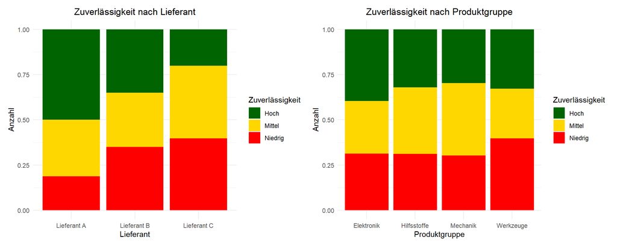

- Wir erkennen, dass Lieferant A einen höheren Anteil an hoher Zuverlässigkeit als Lieferant B und C hat. Lieferant C hat die niedrigste Zuverlässigkeit.
- Umgekehrt lässt sich erkennen, dass Lieferant A den geringsten Anteile an Lieferungen mit niedriger Zuverlässigkeit hat, während Lieferant C den höchsten Anteil der drei Lieferanten hat.
- Bei den Produktgruppen ergibt sich ein homogeneres Bild der Zuverlässigkeiten, wobei Elektronik den höchsten Anteil der Zuverlässigkeit hat und Werkzeuge den niedrigsten.

#### Voraussetzungen Chi-Quadrat Test

- Nominal oder ordinal skalierte Daten –> OK!
- Mindestens 50 Datenpunkte –> 559 gegeben –> OK!
- Daten liegen in Absolutwerten vor –> OK!
- Erwartete Häufigkeiten ≥ 5 –> Prüfung:

Für den ersten Test *(Lieferant - Zuverlässigkeit)*:

```
                Hoch   Mittel  Niedrig
Lieferant A 54.38283 54.38283 51.23435
Lieferant B 67.97853 67.97853 64.04293
Lieferant C 67.63864 67.63864 63.72272
```

für den zweiten Test *(Produktgruppe - Zuverlässigkeit):*

```
                Hoch   Mittel  Niedrig
Elektronik  65.25939 65.25939 61.48122
Hilfsstoffe 37.04830 37.04830 34.90340
Mechanik    62.88014 62.88014 59.23971
Werkzeuge   24.81216 24.81216 23.37567
```

Alle erwarteten Häufigkeiten sind größer als 5. Damit sind alle Voraussetzungen für den Chi-Quadrat Test erfüllt.

#### Chi-Quadrat Test

```
    Pearson's Chi-squared test

data:  Lieferant and Zuverlässigkeit
X-squared = 39.987, df = 4, p-value = 4.355e-08
```

Wir erkennen, dass es statistisch signifikante Unterschiede zwischen den Lieferanten und der Zuverlässigkeit gibt.

```
    Pearson's Chi-squared test

data:  Produktgruppe and Zuverlässigkeit
X-squared = 8.9333, df = 6, p-value = 0.1774
```

Wir erkennen, dass es **keine** statistisch signifikante Unterschiede zwischen den Produktkategorien und der Zuverlässigkeit gibt.

#### Zusammenfassung

Aufgabe 1a) *“Unterscheidet sich die Produktzuverlässigkeit der einzelnen Lieferanten signifikant voneinander?”* Antwort: JA

Aufgabe 1b) *“Gibt es einen Zusammenhang zwischen Produktkategorie und Zuverlässigkeit?”* –> Antwort: NEIN

# Aufgabe 2

#### Aufgabenstellung

Eine Veränderung von Produktionsmitteln soll zu einer Absenkung des Energieverbrauchs führen. Im Unternehmen gibt es gewisse Vorbehalte gegen den Einsatz von nicht-parametrischen Verfahren. Überprüfen Sie die Veränderung, wenn möglich, mit einem parametrischen Verfahren. Ein nicht-parametrisches Verfahren ist erst nachfolgend einsetzbar! Wie bewerten Sie die Veränderung?

#### Deskriptive Statistik

```
  Herkömmlich       Neuartig
 Min.   :204.2   Min.   :239.0
 1st Qu.:311.8   1st Qu.:279.7
 Median :348.5   Median :306.3
 Mean   :347.4   Mean   :313.6
 3rd Qu.:380.3   3rd Qu.:329.4
 Max.   :451.5   Max.   :478.7
```

Die Stichproben *‘Herkömmlich’* und *‘Neuartig’* haben eine Standardabweichung von 53.4469923, 52.2781823, eine Schiefe von -0.1568164, 1.2229293 und eine Kurtosis von -0.3295566, 1.5893743.

- Anhand der Tertiärstatistiken erkennen wir, dass unser neuartiges Produktionsmittel im Mittel einen 33 kWh geringeren Leistungsverbrauch hat.
- Ebenfalls erkennen wir, dass unser neuartiges Produktionsmittel eine Rechtsschiefe und eine stark positive Kurtosis aufzeigt.
- Darüber hinaus sehen wir beim neuartigen Produktionsmittel einen merklichen Unterschied zwischen dem Median und dem Mittelwert.
- Die Standardabweichung ist für beide Stichproben annähernd gleich.
- Das herkömmliche Produktionsmittel ist unauffällig und lässt auf eine Normalverteilung schließen.

#### Visualisierung der Daten

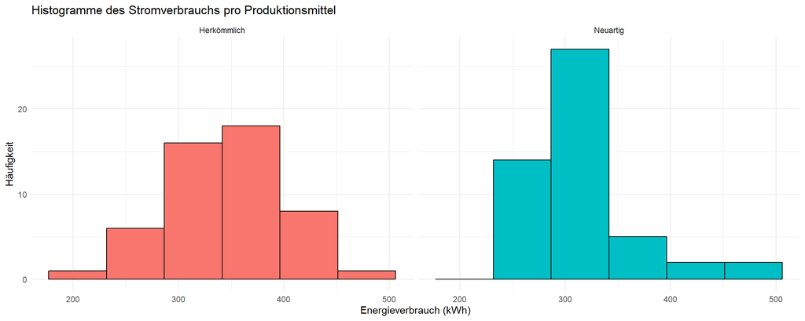

- Das herkömmliche Produktionsmittel zeigt eine annähernd symmetrische Verteilung, während die Verteilung des neuartigen Produktionsmittels die Analyse der Tertiärstatistik bzgl. Kurtosis und Rechtsschiefe bestätigt.

Blicken wir nun auf ein Boxplot und Q-Q Diagramm um einen nähren Einblick zu einzelnen Datenpunkten zu erfahren:

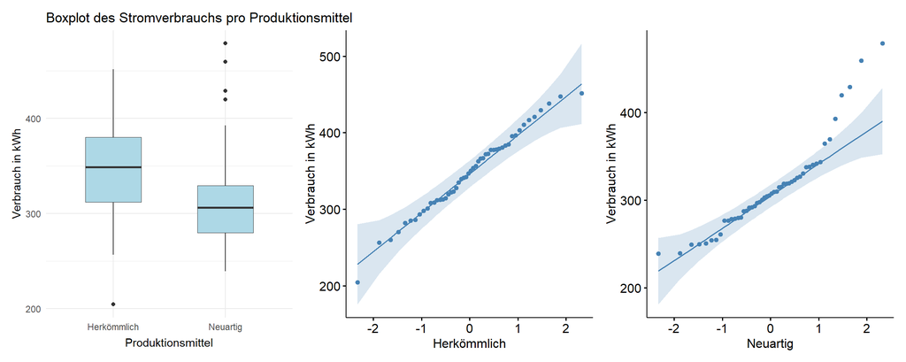

Anhand des Boxplots und der Q-Q Diagramme erkennen wir folgendes:

- Das herkömmliche Produktionsmittel scheint einer Normalverteilung zu folgen. Der Datensatz enthält einen potentiellen Ausreisser nach unten.
- Das neue Produktionsmittel weicht durch die Kurvenform im Q-Q Diagramm stark von der angenommenen Normalverteilung ab. Anhand des Boxplots sehen wir ebenfalls vier potientielle Ausreisser nach oben.

#### Voraussetzungen T-Test für unabhängige Stichproben

- Mindestens intervallskaliert –> OK!
- Keine signifikanten Streuungsunterschiede –> Prüfen:

```
    Bartlett test of homogeneity of variances

data:  kWh by Produktionsmittel
Bartlett's K-squared = 0.023713, df = 1, p-value = 0.8776
```

Da p>0.05 verbleiben wir in H0. Varianzhomogenität ist damit gegeben.

- Keine Ausreisser in den Daten -> Prüfen:

```
    Grubbs test for one outlier

data:  Energieverbrauch$Herkömmlich
G = 2.67975, U = 0.85046, p-value = 0.1384
alternative hypothesis: lowest value 204.22 is an outlier
```

Die Herkömmliche Stichprobe hat mit p>0.05 keinen Ausreisser.

```
    Grubbs test for one outlier

data:  Energieverbrauch$Neuartig
G = 3.15958, U = 0.79211, p-value = 0.0219
alternative hypothesis: highest value 478.73 is an outlier
```

Der höchste Wert 478.73 scheint bei der neuartigen Stichprobe ein Ausreisser zu sein. Da jedoch noch nicht feststeht, ob wir den T-Test benutzen können wird aufs erste verzichtet, diesen zu entfernen. Ebenfalls hat der Datensatz mehrere Extremwerte, die eher für systematische Abweichung durch das Produktionsmittel statt echte Falschwerte spricht und wir diese potentiell behalten.

- Normalverteilung beider Stichproben -> Prüfen:

```
    Shapiro-Wilk normality test

data:  Energieverbrauch$Herkömmlich
W = 0.98862, p-value = 0.9087
```

```
    Shapiro-Wilk normality test

data:  Energieverbrauch$Neuartig
W = 0.8955, p-value = 0.0003423
```

Die Stichprobe des herkömmlichen Produktionsmittels zeigt eine Normalverteilung. Das neue Produktionsmittel allerdings nicht (da p<0.05).

- Da der Kunde ein parametrisches Verfahren bevorzugt, aber die Stichprobe in der aktuellen Form einen T-Test nicht zulässt wird geprüft, ob mit einer Transformation der Daten entgegengesteuert werden kann.

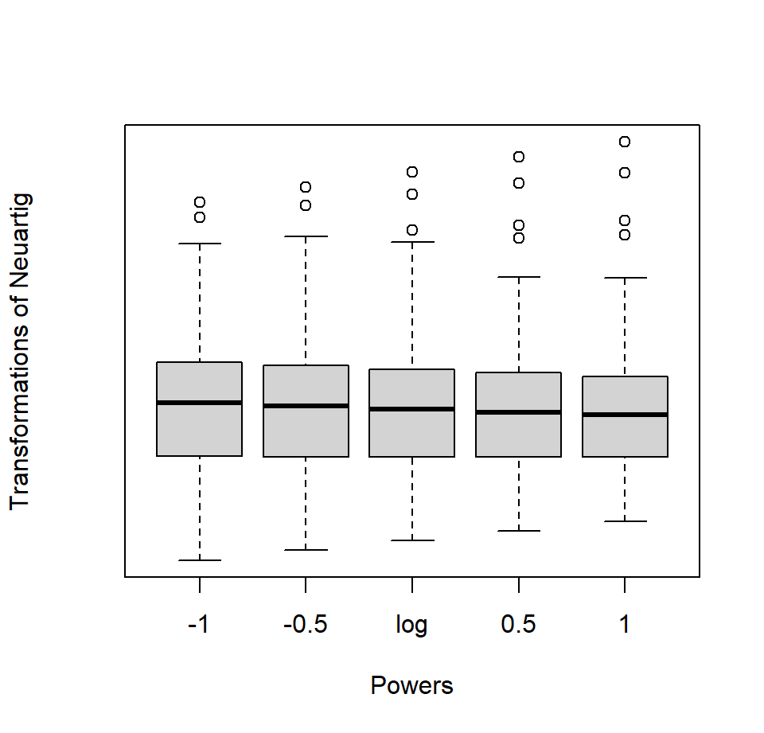

Die Interpretation der Whisker zeigt, dass eine Transformation nicht sinnvoll ist.

Wir wechseln also in den nichtparametrischen Wilcox Test. Wir behalten die Extremwerte der Stichprobe bei, da der Test als Rangsummentest weniger anfällig gegenüber den Extremwerten ist.

#### Test Durchführen

```
    Wilcoxon rank sum test

data:  kWh by Produktionsmittel
W = 1767, p-value = 0.0001825
alternative hypothesis: true location shift is greater than 0
```

#### Zusammenfassung

Das neue Produktionsmittel stellt eine stark signifikante Verbesserung des Energieverbrauchs dar. Es sollte vermutlich dennoch innerbetrieblich analysiert werden, warum das neuartige Produktionsmittel viele Extremwerte hervorbringt.

# Aufgabe 3

#### Aufgabenstellung

Für eine Komponente einer Produktionslinie treten immer wieder Probleme mit der Standzeit der Komponente auf. Diese führen zu höheren Produktionskosten und zu ungeplanten Stillständen.

Die Variante 1 stellt die aktuelle Produktion dar. Die Varianten 2 und 3 sind eigenständige Neulösungen für die betroffene Komponente.

Die Variante 4 stellt nur eine Veränderung der Prozessgeschwindigkeit dar und kann damit als abhängig von Variante 1 angesehen werden.

Welche Variante stellt die beste (längste) Standzeit dar?

#### Vorüberlegungen

- Es liegen vier Gruppen mit intervallskalierten Daten vor.
- Variante 1, 2 und 3 haben jeweils einen vollen Datensatz mit 100 Datenpunkten, Variante 4 hat zwei fehlende Werte, die bei der Stichprobengröße allerdings nicht stören sollten.
- Wir möchten einen möglichen signifikanten Unterschied zwischen den Gruppen untersuchen. Deshalb ist es für uns unerheblich, ob Variante 4 und 1 ähnliche Systeme sind und werden im vorerst als unabhängig betrachtet.
- Zuerst bietet sich eine ANOVA an, um herauszufinden, ob mindestens ein Paar signifikante Unterschiede aufweist.
- Falls ja wird zusätzlich untersucht, welche Variante die beste beste Lösung darstellt durch paarweise T-Tests oder äquivalente Tests.

#### Deskriptive Statistik

```
           vars   n   mean    sd median trimmed   mad    min    max  range  skew kurtosis   se
Variante 1    1 100 500.56 50.68 501.11  501.01 46.49 387.13 622.52 235.39 -0.03    -0.37 5.07
Variante 2    2 100 483.79 42.61 482.73  482.18 40.21 371.27 585.19 213.92  0.21     0.09 4.26
Variante 3    3 100 523.37 60.02 521.78  523.12 64.71 392.88 669.06 276.18  0.06    -0.50 6.00
Variante 4    4  98 515.84 55.62 524.04  514.64 64.92 401.12 629.26 228.14  0.12    -0.86 5.62
```

```
   Variante 1      Variante 2      Variante 3      Variante 4
 Min.   :387.1   Min.   :371.3   Min.   :392.9   Min.   :401.1
 1st Qu.:470.3   1st Qu.:453.9   1st Qu.:482.9   1st Qu.:468.4
 Median :501.1   Median :482.7   Median :521.8   Median :524.0
 Mean   :500.6   Mean   :483.8   Mean   :523.4   Mean   :515.8
 3rd Qu.:532.6   3rd Qu.:509.5   3rd Qu.:567.5   3rd Qu.:553.0
 Max.   :622.5   Max.   :585.2   Max.   :669.1   Max.   :629.3
                                                 NA's   :2
```

- Alle Varianten haben ähnliche Median- und Mittelwerte. Die größte Abweichung gibt es bei Variante 4.
- Keine Variante weißt übermäßige Schiefe auf.
- Bis auf Variante 2 weißen alle Varianten eine leicht negative Kurtosis auf.
- Die Standardabweichung der Varianten schwankt von 42.61 zu 60.02 deutlich.
- Variante 2 scheint bei Betrachtung der Werte die schlechteste Option zu sein, während Variante 3 die beste Option ist.

#### Daten Visualisieren

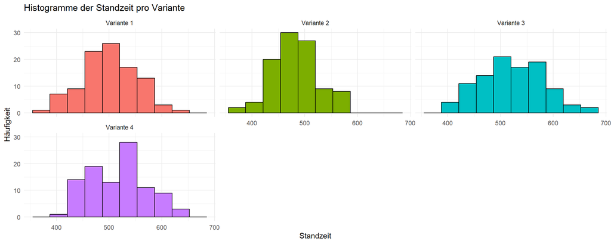

- Die Histogramme der Varianten zeigen annährend eine Normalverteilung auf, die es aber vor allem bei Variante 4 noch zu prüfen gilt.

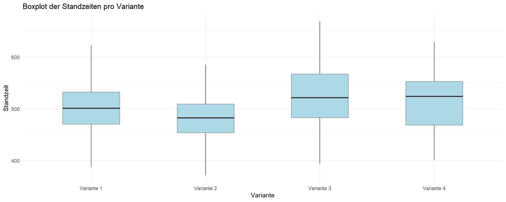

- Das Boxplot zeigt uns deutlich, dass Variante 4 den höchsten Medianwert hat, der allerdings auch wie schon beschrieben verschoben ist.
- Ebenfalls erkennen wir visuell die große Standardabweichung bei Variante 3 und die kleine Abweichung bei Variante 2.

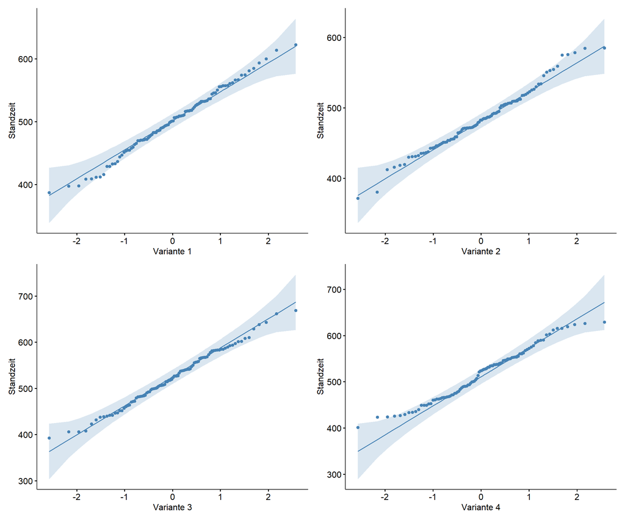

- Das Q-Q Diagramm der Variante 1 zeigt nach unten hin einige Werte, die nah an die Grenze des Konfidenzintervalls heranrücken oder es sogar überschreiten.
- Bei Variante 2 scheren die Werte oben zur oberen Grenze des Konfidenzintervalls, ein bis zwei Werte befinden sich darüber.
- Variante 3 zeigt keine Auffälligkeiten.
- Bei Variante erkennen wir einen deutlichen Knick in der Kurve und Werte, die unten hin das Konfidenzintervall verlassen.
- Weitere Analysen werden als Voraussetzung für die ANOVA im folgenden geprüft

#### Voraussetzungen für einfaktorielle ANOVA

- Mindestens intervallskalierte abhängige Variable -> OK!
- Merkmalsausprägungen müssen unabhängig voneinander sein -> Als OK angenommen!
- Normalverteilung der abhängigen Variable in allen Gruppen -> Prüfen:

```
# A tibble: 4 × 2
  Variante        p
  <chr>       <dbl>
1 Variante 1 0.885
2 Variante 2 0.352
3 Variante 3 0.780
4 Variante 4 0.0645
```

**Evaluierung:** Alle Varianten weißen einen p>0.05 auf und sind somit normalverteilt.

- Gleiche Varianz in allen Gruppen -> Prüfen:

```
Levene's Test for Homogeneity of Variance (center = median)
       Df F value   Pr(>F)
group   3  5.3462 0.001282 **
      394
---
Signif. codes:  0 '***' 0.001 '**' 0.01 '*' 0.05 '.' 0.1 ' ' 1
```

**Evaluierung:** Mit p<0.05 fallen wir aus H0. Unsere Daten weisen somit keine Varianzhomogenität auf. Wir müssen somit den nicht-parametrischen **Kruskal-Wallis Test**.

#### Kruskal-Wallis Test

```
    Kruskal-Wallis rank sum test

data:  Standzeiten
Kruskal-Wallis chi-squared = 28.974, df = 3, p-value = 2.267e-06
```

**Evaluierung:** Mit p<0.05 gehen wir in die Alternativhypothese. Es gibt somit mindestens einen signifikanten Unterschied zwischen den Gruppen innerhalb des Datensatzes.

#### Paarweiser Vergleich

Mit dem Pairwise Wilcox Test überprüfen wir die einzelnen Gruppenpaare:

```
    Pairwise comparisons using Wilcoxon rank sum test with continuity correction

data:  Standzeiten_long$Standzeit and Standzeiten_long$Variante

           Variante 1 Variante 2 Variante 3
Variante 2 0.0550     -          -
Variante 3 0.0440     6e-06      -
Variante 4 0.4820     0.0004     1.0000

P value adjustment method: bonferroni
```

**Evaluierung:** Wir erkennen folgende signifikante Zusammenhänge:

- Variante 1 : Variante 3
- Variante 2 : Variante 3
- Variante 2 : Variante 4

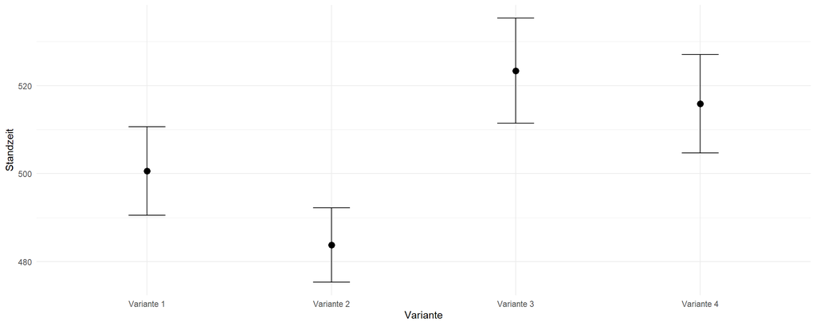

#### Zusammenfassung

Die aktuelle Produktion (Variante 1) ist der Variante 3 signifikant unterlegen - hier würde sich ein Wechsel also lohnen. Der Unterschied zwischen Variante 1 und 4 ist nicht signifikant, könnte allerdings durchaus interessant sein, da Variante 4 (als Variation von Variante 1) vermutlich geringeren Umsetzungsaufwand bedeutet. Hier könnten weitere Tests Aufklärung verschaffen.

# Aufgabe 4

#### Aufgabenstellung

In einem Prozessschritt werden einzelne Bauteile des Produktes verklebt. Allgemein besteht die Ansicht „Viel hilft viel!“. Deshalb hat man mehrere Faktoren des Prozesses auf ein hohe und damit kostspielige Faktorstufe eingestellt. Nun kommen Zweifel auf, ob tatsächlich alle Faktoren im Prozess wichtig sind. Untersuchen Sie die vorliegenden Daten auf Wirksamkeit der Faktoren im Klebeprozess und beurteilen Sie diese. Die Kennzahl der Qualität ist intervallskaliert und es gilt: Je größer, je besser…

#### Vorüberlegungen

- Wir haben 3 kategoriale Spalten (D*auer, Feuchte, Temperatur*) mit den Ausprägungen *‘Hoch’* und *‘Tief’.*
- Eine intervallskalierte Spalte *‘Qualität’.*
- Wir möchten herausfinden, welche Faktoren oder Interaktionseffekte aus Faktoreneinstellungen einen signifikanten Einfluss im Klebeprozess haben.
- Können wir herausfinden, welche Kombination die höchste Qualität hat?
- Eine **mehrfaktorielle Varianzanalyse** lässt uns das prüfen.

#### Daten Visualisieren

Wir fassen die einzelnen Datenpunkte zusammen zu Gruppen und lassen uns die Mittelwerte und Standardabweichung angeben um einen ersten Eindruck zu bekommen:

```
  Dauer Feuchte Temperatur   Mittel       SD  N
1  Hoch    Hoch       Hoch 80.59967 5.526718 30
2  Hoch    Hoch       Tief 74.99533 3.780424 30
3  Hoch    Tief       Hoch 85.80400 5.772817 30
4  Hoch    Tief       Tief 89.49300 5.477318 30
5  Tief    Hoch       Hoch 80.48067 5.697917 30
6  Tief    Hoch       Tief 75.26000 3.779135 30
7  Tief    Tief       Hoch 83.83067 6.099232 30
8  Tief    Tief       Tief 89.92900 4.980335 30
```

**Evalutation:**

- Wir erhalten insgesamt 8 Gruppen durch Kombinationen aus Dauer, Feuchte und Temperatur. Jede Gruppe hat 30 Datenpunkte.
- Die Standardabweichung bewegt sich für die einzelnen Gruppen von 3.7 und 6.1.
- Den höchsten Mittelwert hat die Kombination *Tief-Tief-Tief*.
- Den niedrigesten Mittelwert hat die *Kombination Dauer:Hoch Feuchte:Hoch, Temperatur:Tief*.

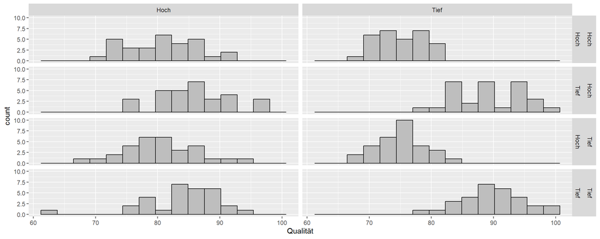

- Anhand der Histogramme können wir sehen, dass die Kombination *Tief-Tief-Tief* die höchste Qualität zu liefern scheint.
- Die Verteilungen sehen bei einigen Gruppen nicht zwingend normalverteilt aus und müssen näher geprüft werden.

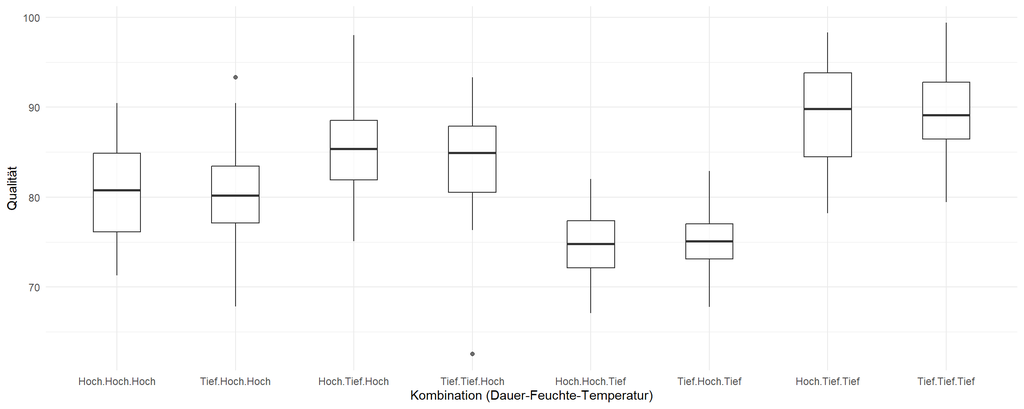

- Anhand des Boxplots erkennen wir einen auffällig hohen Wert in der Kombination *Tief-Hoch-Hoch* und einen sehr stark auffälligen Wert in der Kombination *Tief-Tief-Hoch*. Wir prüfen diese Gruppen auf Ausreisser:

```
    Grubbs test for one outlier

data:  thh$Qualität
G = 2.25334, U = 0.81888, p-value = 0.2856
alternative hypothesis: highest value 93.32 is an outlier
```

```
    Grubbs test for one outlier

data:  tth$Qualität
G = 3.49235, U = 0.56493, p-value = 0.001102
alternative hypothesis: lowest value 62.53 is an outlier
```

- Der Wert 93.32 *(Tief-Hoch-Hoch)* ist kein Ausreisser.
- Der Wert 62.53 *(Tief-Tief-Hoch)* ist mit p<0.05 ein Ausreisser und wird vom Datensatz entfernt.

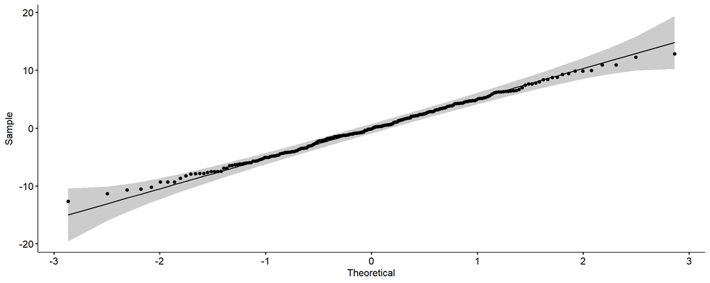

- Anhand des Q-Q Diagramms erkennen wir eine Normalverteilung der Daten.

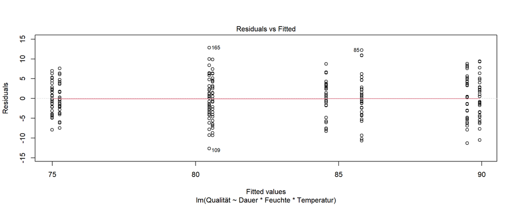

- Anhand der Residuen erkennen wir Varianzhomogenität

#### Voraussetzungen mehrfaktorielle Varianzanalyse

- Mindestens intervallskalierte abhängige Variable –> OK!
- Merkmalsausprägungen müssen unabhängig voneinander sein (falls nicht: ANOVA mit Messwiederholung…) –> OK!
- Normalverteilung der abhängigen Variable innerhalb der einzelnen Gruppen –> Prüfen:

```
# A tibble: 8 × 4
# Groups:   Dauer, Feuchte [4]
  Dauer Feuchte Temperatur p_value
  <chr> <chr>   <chr>        <dbl>
1 Hoch  Hoch    Hoch         0.445
2 Hoch  Hoch    Tief         0.781
3 Hoch  Tief    Hoch         0.577
4 Hoch  Tief    Tief         0.331
5 Tief  Hoch    Hoch         0.997
6 Tief  Hoch    Tief         0.916
7 Tief  Tief    Hoch         0.162
8 Tief  Tief    Tief         0.947
```

**Evaluation:** Alle Kombinationen sind normalverteilt.

- Gleiche Varianz aller Gruppen -> Prüfen:

```
Levene's Test for Homogeneity of Variance (center = median)
       Df F value Pr(>F)
group   7  1.4959 0.1695
      231
```

**Evaluation:** Da p>0.05 können wir von Varianzhomogenität ausgehen.

Die Voraussetzungen für eine Multifaktorielle ANOVA sind also erfüllt.

#### Multifaktorielle ANOVA

```
ANOVA Table (type II tests)

                    Effect DFn DFd       F        p p<.05      pes
1                    Dauer   1 231   0.060 8.06e-01       0.000262
2                  Feuchte   1 231 220.206 1.95e-35     * 0.488000
3               Temperatur   1 231   0.519 4.72e-01       0.002000
4            Dauer:Feuchte   1 231   0.132 7.17e-01       0.000570
5         Dauer:Temperatur   1 231   0.624 4.30e-01       0.003000
6       Feuchte:Temperatur   1 231  58.515 5.42e-13     * 0.202000
7 Dauer:Feuchte:Temperatur   1 231   0.247 6.20e-01       0.001000
```

**Evalutation:** Wir erkennen zwei signifikante Effekte: Feuchte und die Interaktion zwischen Feuchte und Temperatur.

#### Zusammenfassung

Die Variablen *Dauer* hat keine Auswirkungen auf den Klebeprozess und kann somit auf die kostsparende Einstellung gestellt werden. Die signifikante Interaktion zwischen *Feuchte* und *Temperatur* lässt den Schluss zu, dass beide auf die kostengünstige und zugleich qualitativ beste Option tieft gestellt werden können.